# Building an MDP model

Lars Relund lars@relund.dk

2026-06-22

Building and solving an MDP is done in two steps. First, the MDP is built and saved in a set of binary files. Next, you load the MDP into memory from the binary files and apply various algorithms to the model.

In this vignette we focus on the first step, i.e. building and saving the model to a set of binary files.

```r
library(MDP2)
```

## An infinite semi-MDP

An *infinite-horizon semi-MDP* considers a sequential decision problem over an infinite number of *stages*. Let $I$ denote the finite set of system states at stage $n$. Note we assume that the semi-MDP is *homogeneous*, i.e the state space is independent of stage number. When *state* $i \in I$ is observed, an *action* $a$ from the finite set of allowable actions $A(i)$ must be chosen which generates *reward* $r(i,a)$. Moreover, let $\tau(i,a)$ denote the *stage length* of action $a$, i.e. the expected time until the next decision epoch (stage $n+1$) given action $a$ and state $i$. Finally, let $p_{ij}(a)$ denote the *transition probability* of obtaining state $j\in I$ at stage $n+1$ given that action $a$ is chosen in state $i$ at stage $n$. A policy is a decision rule/function that assigns to each state in the process an action. Note if the stage length is the same for all states and actions the we have a regular *infinite-horizon MDP*.

Let us consider Example 6.1.1 in Tijms (2003). At the beginning of each day a piece of equipment is inspected to reveal its actual working condition. The equipment will be found in one of the working conditions $i = 1,\ldots, N$ where the working condition $i$ is better than the working condition $i+1$. The equipment deteriorates in time. If the present working condition is $i$ and no repair is done, then at the beginning of the next day the equipment has working condition $j$ with probability $q_{ij}$. It is assumed that $q_{ij}=0$ for $j<i$ and $\sum_{j\geq i}q_{ij}=1$. The working condition $i=N$ represents a malfunction that requires an enforced repair taking two days. For the intermediate states $i$ with $1<i<N$ there is a choice between preventively repairing the equipment and letting the equipment operate for the present day. A preventive repair takes only one day. A repaired system has the working condition $i=1$. The cost of an enforced repair upon failure is $C_{f}$ and the cost of a preemptive repair in working condition $i$ is $C_{p}(i)$. We wish to determine a maintenance rule which minimizes the long-run average repair cost per day.

To formulate this problem as an infinite horizon semi-MDP the set of possible states of the system is chosen as
$$I=\{1,2,\ldots,N\}.$$
State $i$ corresponds to the situation in which an inspection reveals working condition $i$. Define actions
$$a=\left\{\begin{array}{ll}
nr & \text{if no repair.}\\
pr & \text{if preventive repair.}\\
fr & \text{if forced repair.}\\
\end{array}\right.$$
The set of possible actions in state $i$ is chosen as $A(1)=\{nr\},\ A(i)=\{nr,pr\}$ for $1<i<N, A(N)=\{fr\}$. The one-step transition probabilities $p_{ij}(a)$ are given by $p_{ij}(0) = q_{ij}$ for $1\leq i<N$, $p_{i1}(1) = 1$ for $1<i<N$, $p_{N1}(2)=1$ and zero otherwise. The one-step costs $c_{i}(a)$ are given by $c_{i}(0)=0,\ c_{i}(1)=C_{p}(i)$ and $c_{N}(2)=C_{f}$. The stage length until next decision epoch are $\tau(i,a) = 1, 0\leq i < N$ and $\tau(N,a) = 2$.

Assume that the number of possible working conditions equals $N=5$, i.e. the number of states are:

```r
N <- 5
states <- tibble::tibble(
  idx = 1:N - 1,
  label = paste0("i = ", 1:N)
)
states
```

```
#> # A tibble: 5 × 2
#>     idx label
#>   <dbl> <chr>
#> 1     0 i = 1
#> 2     1 i = 2
#> 3     2 i = 3
#> 4     3 i = 4
#> 5     4 i = 5
```

Note each state are given an index and are always numbered from zero. The repair costs (negative numbers since the MDP optimize based on rewards) are:

```r
Cf <- -10
Cp <- c(0, -7, -7, -5)
```

The deterioration probabilities $q_{ij}$ are

```r
Q <- matrix(
  c(
    0.90, 0.10, 0, 0, 0,
    0, 0.80, 0.10, 0.05, 0.05,
    0, 0, 0.70, 0.10, 0.20,
    0, 0, 0, 0.50, 0.50
  ),
  nrow = 4, byrow = T
)
```

To build the model we need transition probabilities and the state index for the corresponding transitions. We may define function:

```r
#' Transition probabilities
#' @param i State (1 <= i <= N).
#' @param a Action (`nr`, `pr` or `fr`).
#' @return A list with non-zero transition probabilities and state index of the transitions.
trans_pr <- function(i, a) {
  pr <- NULL
  idx <- NULL
  if (a == "nr") {
    pr <- Q[i, ]
    idx <- which(pr > 0) # only consider trans pr > 0
    pr <- pr[idx]
    idx <- idx - 1 # since state index is state-1
  }
  if (a == "pr" | a == "fr") {
    pr <- 1
    idx <- 0
  }
  return(list(pr = pr, idx = idx))
}
```

The transition probabilities for state 1 and the “no repair” action is now:

```r
trans_pr(1, "nr")
```

```
#> $pr
#> [1] 0.9 0.1
#>
#> $idx
#> [1] 0 1
```

The state-expanded hypergraph representing the semi-MDP with infinite time-horizon is shown in Figure 1. Here the first stage is visualized. Each node corresponds to a specific state in the MDP. A directed hyperarc is defined for each possible action. For instance, the state/node corresponding to working condition $i=2$ and the two hyperarcs with head in this node corresponds to the two possible actions preventive and no repair. Note the tails of a hyperarc represent a possible transition ($p_{ij}(a)>0$).

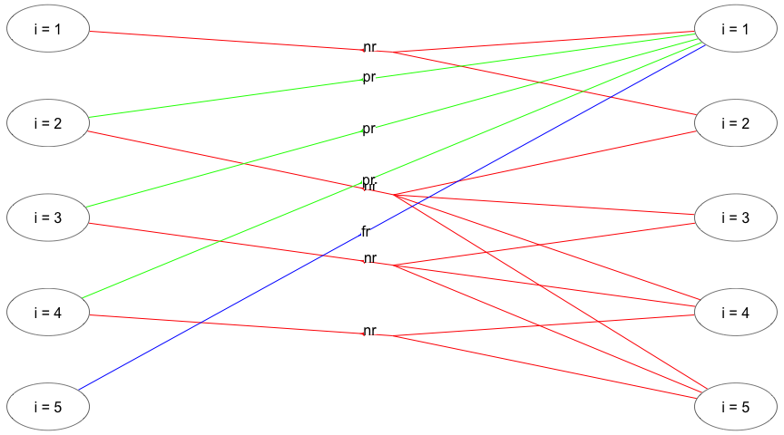

Figure 1: The state-expanded hypergraph for the semi-MDP.

To build the semi-MDP, we use the `binary_mdp_writer` where the model can be built using either matrices or an hierarchical structure. We first illustrate how to use the hierarchical structure.

```r
labels <- states$label
w <- binary_mdp_writer("hct611-1_") # use prefix hct611-1_ to the files
w$set_weights(c("Duration", "Net reward"))
w$process() # founder process
w$stage() # a stage with states
w$state(label = labels[1]) # state 1
lst <- trans_pr(1, "nr")
w$action(label = "nr", weights = c(1, 0), pr = lst$pr, id = lst$id, end = TRUE)
w$end_state() # end state 1
for (i in 2:(N - 1)) { # states 2 to N-1
  w$state(label = labels[i])
  lst <- trans_pr(i, "nr")
  w$action(label = "nr", weights = c(1, 0), pr = lst$pr, id = lst$id, end = TRUE)
  lst <- trans_pr(i, "pr")
  w$action(label = "pr", weights = c(1, Cp[i]), pr = lst$pr, id = lst$id, end = TRUE)
  w$end_state()
}
w$state(label = labels[N])
lst <- trans_pr(N, "fr")
w$action(label = "fr", weights = c(2, Cf), pr = lst$pr, id = lst$id, end = TRUE)
w$end_state()
w$end_stage() # end stage
w$end_process() # end process
w$close_writer() # close the binary files
```

```
#>
#>   Statistics:
#>     states : 5
#>     actions: 8
#>     weights: 2
#>
#>   Closing binary MDP writer.
```

Observe that

- We build the model with two weights applied to each action “Duration” and “Net reward”. That is, when we specify an action, we must add two weights. “Duration” equals 1 day except in state $i=N$ where a forced repair takes 2 days.
- The process is built using first a `process` which contains a `stage` (we only specify one stage, since we have a homogeneous semi-MDP over an infinite horizon) which contains `state`s which contains `action`s.
- Transitions of an `action` are specified using the `pr` and `id` parameter.
- The `end = TRUE` argument in an action specify that the action is a normal action that not define a sub-process.
- The model is saved in a set of binary files with prefix `hct611-1_`.

Building the model may be error prone and you may use `get_bin_info_states()` and `get_bin_info_actions()` to retrieve info about the content of the binary files:

```r
get_bin_info_states("hct611-1_")
```

```
#> # A tibble: 5 × 3
#>    s_id stage_str label
#>   <dbl> <chr>     <chr>
#> 1     0 0,0       i = 1
#> 2     1 0,1       i = 2
#> 3     2 0,2       i = 3
#> 4     3 0,3       i = 4
#> 5     4 0,4       i = 5
```

```r
get_bin_info_actions("hct611-1_")
```

```
#> # A tibble: 8 × 8
#>     aId  s_id scope   index   pr                Duration `Net reward` label
#>   <dbl> <int> <chr>   <chr>   <chr>                <dbl>        <dbl> <chr>
#> 1     0     0 1,1     0,1     0.9,0.1                  1            0 nr
#> 2     1     1 1,1,1,1 1,2,3,4 0.8,0.1,0.05,0.05        1            0 nr
#> 3     2     1 1       0       1                        1           -7 pr
#> 4     3     2 1,1,1   2,3,4   0.7,0.1,0.2              1            0 nr
#> 5     4     2 1       0       1                        1           -7 pr
#> 6     5     3 1,1     3,4     0.5,0.5                  1            0 nr
#> 7     6     3 1       0       1                        1           -5 pr
#> 8     7     4 1       0       1                        2          -10 fr
```

The model can be loaded using the `load_mdp()` function.

The model can also be built by specifying a set of matrices. Note this way of specifying **only work** for infinite-horizon semi-MDPs (and not finite-horizon or hierarchical models). Specify a list of probability matrices (one for each action) where each row/state contains the transition probabilities (all zero if the action is not used in a state), a matrix with rewards and a matrix with stage lengths (row = state, column = action).

```r
## Define probability matrices
P <- list()
# a = nr (no repair)
P[[1]] <- as.matrix(rbind(Q, 0))

# a = pr (preventive repair)
Z <- matrix(0, nrow = N, ncol = N)
Z[2, 1] <- Z[3, 1] <- Z[4, 1] <- 1
P[[2]] <- Z

# a = fr (forced repair)
Z <- matrix(0, nrow = N, ncol = N)
Z[5, 1] <- 1
P[[3]] <- Z

## Rewards, a 5x3 matrix with one column for each action
R <- matrix(0, nrow = N, ncol = 3)
R[2:4, 2] <- Cp[2:4]
R[5, 3] <- Cf

## State lengths, a 5x3 matrix with one column for each action
D <- matrix(1, nrow = N, ncol = 3)
D[5, 3] <- 2

## Build model using the matrix specification
w <- binary_mdp_writer("hct611-2_")
w$set_weights(c("Duration", "Net reward"))
w$process(P, R, D)
w$close_writer()
```

```
#>
#>   Statistics:
#>     states : 5
#>     actions: 8
#>     weights: 2
#>
#>   Closing binary MDP writer.
```

## A finite-horizon semi-MDP

A *finite-horizon semi-MDP* considers a sequential decision problem over $N$ *stages*. Let $I_{n}$ denote the finite set of system states at stage $n$. When *state* $i \in I_{n}$ is observed, an *action* $a$ from the finite set of allowable actions $A_n(i)$ must be chosen, and this decision generates *reward* $r_{n}(i,a)$. Moreover, let $\tau_n(i,a)$ denote the *stage length* of action $a$, i.e. the expected time until the next decision epoch (stage $n+1$) given action $a$ and state $i$. Finally, let $p_{ij}(a,n)$ denote the *transition probability* of obtaining state $j\in I_{n+1}$ at stage $n+1$ given that action $a$ is chosen in state $i$ at stage $n$.

Consider a small machine repair problem used as an example in Nielsen and Kristensen (2006) where the machine is always replaced after 4 years. The state of the machine may be: good, average, and not working. Given the machine’s state we may maintain the machine. In this case the machine’s state will be good at the next decision epoch. Otherwise, the machine’s state will not be better at next decision epoch. When the machine is bought it may be either in state good or average. Moreover, if the machine is not working it must be replaced.

The problem of when to replace the machine can be modeled using a Markov decision process with $N=5$ decision epochs. We use system states `good`, `average`, `not working` and dummy state `replaced` together with actions buy (`buy`), maintain (`mt`), no maintenance (`nmt`), and replace (`rep`). The set of states at stage zero $S_{0}$ contains a single dummy state `dummy` representing the machine before knowing its initial state. The only possible action is `buy`.

The cost of buying the machine is 100 with transition probability of 0.7 to state `good` and 0.3 to state `average`. The reward (scrap value) of replacing a machine is 30, 10, and 5 in state `good`, `average` and `not working`, respectively. The reward of the machine given action `mt` are 55, 40, and 30 in state `good`, `average` and `not working`, respectively. Moreover, the system enters state 0 with probability 1 at the next stage. Finally, the reward, transition states and probabilities given action $a=$`nmt` are given by:

| $n:s$ | $1:$ `good` | $1:$ `average` | $2:$ `good` | $2:$ `average` | $3:$ `good` | $3:$ `average` |
| --- | --- | --- | --- | --- | --- | --- |
| $r_n(i,a)$ | 70 | 50 | 70 | 50 | 70 | 50 |
| $j$ | $\{0,1\}$ | $\{1,2\}$ | $\{0,1\}$ | $\{1,2\}$ | $\{0,1\}$ | $\{1,2\}$ |
| $p_{ij}(a,n)$ | $\{0.6,0.4\}$ | $\{0.6,0.4\}$ | $\{0.5,0.5\}$ | $\{0.5,0.5\}$ | $\{0.2,0.8\}$ | $\{0.2,0.8\}$ |

We build the MDP (all actions have same length) using the `binary_mdp_writer()` function:

```r
prefix <- "machine1_"
w <- binary_mdp_writer(prefix)
w$set_weights(c("Net reward"))
w$process()
w$stage() # stage n=0
w$state(label = "dummy")
w$action(label = "buy", weights = -100, pr = c(0.7, 0.3), id = c(0, 1), end = TRUE)
w$end_state()
w$end_stage()
w$stage() # stage n=1
w$state(label = "good")
w$action(label = "mt", weights = 55, pr = 1, id = 0, end = TRUE)
w$action(label = "nmt", weights = 70, pr = c(0.6, 0.4), id = c(0, 1), end = TRUE)
w$end_state()
w$state(label = "average")
w$action(label = "mt", weights = 40, pr = 1, id = 0, end = TRUE)
w$action(label = "nmt", weights = 50, pr = c(0.6, 0.4), id = c(1, 2), end = TRUE)
w$end_state()
w$end_stage()
w$stage() # stage n=2
w$state(label = "good")
w$action(label = "mt", weights = 55, pr = 1, id = 0, end = TRUE)
w$action(label = "nmt", weights = 70, pr = c(0.5, 0.5), id = c(0, 1), end = TRUE)
w$end_state()
w$state(label = "average")
w$action(label = "mt", weights = 40, pr = 1, id = 0, end = TRUE)
w$action(label = "nmt", weights = 50, pr = c(0.5, 0.5), id = c(1, 2), end = TRUE)
w$end_state()
w$state(label = "not working")
w$action(label = "mt", weights = 30, pr = 1, id = 0, end = TRUE)
w$action(label = "rep", weights = 5, pr = 1, id = 3, end = TRUE)
w$end_state()
w$end_stage()
w$stage() # stage n=3
w$state(label = "good")
w$action(label = "mt", weights = 55, pr = 1, id = 0, end = TRUE)
w$action(label = "nmt", weights = 70, pr = c(0.2, 0.8), id = c(0, 1), end = TRUE)
w$end_state()
w$state(label = "average")
w$action(label = "mt", weights = 40, pr = 1, id = 0, end = TRUE)
w$action(label = "nmt", weights = 50, pr = c(0.2, 0.8), id = c(1, 2), end = TRUE)
w$end_state()
w$state(label = "not working")
w$action(label = "mt", weights = 30, pr = 1, id = 0, end = TRUE)
w$action(label = "rep", weights = 5, pr = 1, id = 3, end = TRUE)
w$end_state()
w$state(label = "replaced")
w$action(label = "dummy", weights = 0, pr = 1, id = 3, end = TRUE)
w$end_state()
w$end_stage()
w$stage() # stage n=4
w$state(label = "good", end = TRUE)
w$state(label = "average", end = TRUE)
w$state(label = "not working", end = TRUE)
w$state(label = "replaced", end = TRUE)
w$end_stage()
w$end_process()
w$close_writer()
```

```
#>
#>   Statistics:
#>     states : 14
#>     actions: 18
#>     weights: 1
#>
#>   Closing binary MDP writer.
```

Note that at each stage the states are numbered using index starting from zero such that e.g. `w$action(label="nmt", weights=50, pr=c(0.2,0.8), id=c(1,2), end=TRUE)` define an action with transition to states with indices 1 and 2 at the next stage with probability 0.2 and 0.8, respectively.

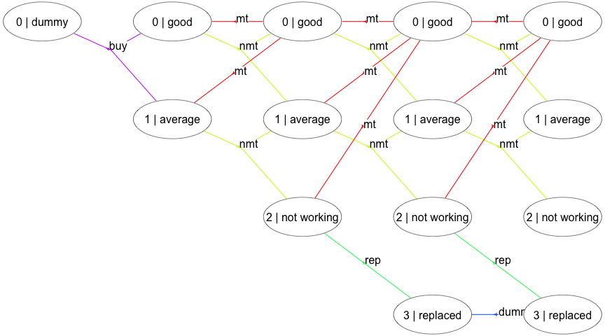

Figure 2: A finite-horizon MDP

## An infinite-horizon HMDP

A hierarchical MDP is an MDP with parameters defined in a special way, but nevertheless in accordance with all usual rules and conditions relating to such processes (Kristensen and Jørgensen (2000)). The basic idea of the hierarchical structure is that stages of the process can be expanded to a so-called *child process*, which again may expand stages further to new child processes leading to multiple levels. To illustrate consider the HMDP shown in Figure 3. The process has three levels. At `Level 2` we have a set of finite-horizon semi-MDPs (one for each oval box) which all can be represented using a state-expanded hypergraph (hyperarcs not shown, only hyperarcs connecting processes are shown). A semi-MDP at `Level 2` is uniquely defined by a given state $s$ and action $a$ of its *parent process* at `Level 1` (illustrated by the arcs with head and tail node at `Level 1` and `Level 2`, respectively). Moreover, when a child process at `Level 2` terminates a transition from a state $s\in \mathcal{S}_{N}$ of the child process to a state at the next stage of the parent process occur (illustrated by the (hyper)arcs having head and tail at `Level 2` and `Level 1`, respectively).

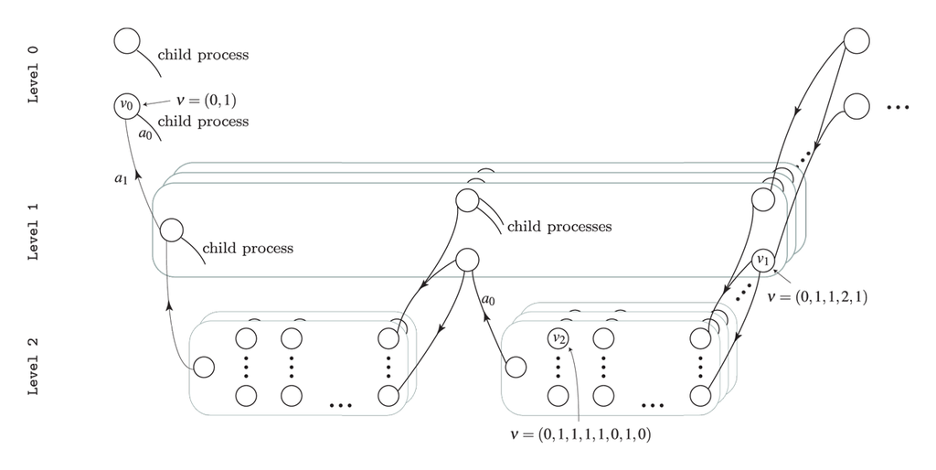

Figure 3: The state-expanded hypergraph of the first stage of a hierarchical MDP. Level 0 indicate the founder level, and the nodes indicates states at the different levels. A child process (oval box) is represented using its state-expanded hypergraph (hyperarcs not shown) and is uniquely defined by a given state and action of its parent process.

Since a child process is always defined by a stage, state and action of the parent process we have that for instance a state at Level 1 can be identified using an index vector $\nu=(n_{0},s_{0},a_{0},n_{1},s_{1})$ where $s_1$ is the state id at the given stage $n_1$ in the process defined by the action $a_0$ in state $s_0$ at stage $n_0$. Note all values are ids starting from zero, e.g. if $s_1=0$ it is the first state at the corresponding stage and if $a_0=2$ it is the third action at the corresponding state. In general a state $s$ and action $a$ at level $l$ can be uniquely identified using
$$\begin{aligned}
\nu_{s}&=(n_{0},s_{0},a_{0},n_{1},s_{1},\ldots,n_{l},s_{l}) \\
\nu_{a}&=(n_{0},s_{0},a_{0},n_{1},s_{1},\ldots,n_{l},s_{l},a_{l}).
\end{aligned}$$
The index vectors for state $v_0$, $v_1$ and $v_2$ are illustrated in Figure 3.

Let us try to solve a small problem from livestock farming, namely the cow replacement problem where we want to represent the age of the cow, i.e. the lactation number of the cow. During a lactation a cow may have a high, average or low yield. We assume that a cow is always replaced after 4 lactations.

In addition to lactation and milk yield we also want to take the genetic merit into account which is either bad, average or good. When a cow is replaced we assume that the probability of a bad, average or good heifer is the same.

We formulate the problem as a HMDP with 2 levels. At level 0 the states are the genetic merit and the length of a stage is a life of a cow. At level 1 a stage describe a lactation and states describe the yield. Decisions at level 1 are `keep` or `replace`.

Note the MDP runs over an infinite time-horizon at the founder level where each state (genetic merit) define a semi-MDP at level 1 with 4 lactations.

To generate the MDP we need to know the weights and transition probabilities which are provided in a CSV file. To ease the understanding we provide 2 functions for reading from the CSV:

```r
library(magrittr)
cow_df <- readr::read_csv("vignette_files/cow.csv")
cow_df
```

```
#> # A tibble: 66 × 16
#>       s0    n1    s1 label   Duration Reward Output  scp0  idx0   pr0  scp1  idx1   pr1
#>    <dbl> <dbl> <dbl> <chr>      <dbl>  <dbl>  <dbl> <dbl> <dbl> <dbl> <dbl> <dbl> <dbl>
#>  1     0     0     0 Dummy          0      0      0     1     0 0.333     1     1 0.333
#>  2     0     1     0 Keep           1   6000   3000     1     0 0.6       1     1 0.3
#>  3     0     1     0 Replace        1   5000   3000     0     0 0.333     0     1 0.333
#>  4     0     1     1 Keep           1   8000   4000     1     0 0.2       1     1 0.6
#>  5     0     1     1 Replace        1   7000   4000     0     0 0.333     0     1 0.333
#>  6     0     1     2 Keep           1  10000   5000     1     0 0.1       1     1 0.3
#>  7     0     1     2 Replace        1   9000   5000     0     0 0.333     0     1 0.333
#>  8     0     2     0 Keep           1   8000   4000     1     0 0.6       1     1 0.3
#>  9     0     2     0 Replace        1   7000   4000     0     0 0.333     0     1 0.333
#> 10     0     2     1 Keep           1  10000   5000     1     0 0.2       1     1 0.6
#> # ℹ 56 more rows
#> # ℹ 3 more variables: scp2 <dbl>, idx2 <dbl>, pr2 <dbl>
```

```r
# Weights given a state at level 2
lev1_w <- function(s0Idx, n1Idx, s1Idx, a1Lbl) {
  return(cow_df %>%
    dplyr::filter(s0 == s0Idx & n1 == n1Idx & s1 == s1Idx & label == a1Lbl) %>%
    dplyr::select(Duration, Reward, Output) %>% as.numeric())
}
lev1_w(2, 2, 1, "Keep") # good genetic merit, lactation 2, avg yield, keep action
```

```
#> [1]     1 14000  7000
```

```r
# Trans pr given a state at level 2
lev1_pr <- function(s0Idx, n1Idx, s1Idx, a1Lbl) {
  return(cow_df %>%
    dplyr::filter(s0 == s0Idx & n1 == n1Idx & s1 == s1Idx & label == a1Lbl) %>%
    dplyr::select(scp0:last_col()) %>% as.numeric())
}
lev1_pr(2, 2, 1, "Replace") # good genetic merit, lactation 2, avg yield, replace action
```

```
#> [1] 0.0000000 0.0000000 0.3333333 0.0000000 1.0000000 0.3333333 0.0000000 2.0000000
#> [9] 0.3333333
```

We can now generate the model with three weights

```r
lblS0 <- c('Bad genetic level', 'Avg genetic level', 'Good genetic level')
lblS1 <- c('Low yield', 'Avg yield', 'High yield')
prefix<-"cow_"
w<-binary_mdp_writer(prefix)
w$set_weights(c("Duration", "Net reward", "Yield"))
w$process()
  w$stage()   # stage 0 at founder level
    for (s0 in 0:2) {
      w$state(label=lblS0[s0+1])   # state at founder
        w$action(label="Keep", weights=c(0,0,0), prob=c(2,0,1))   # action at founder
          w$process()
            w$stage()   # dummy stage at level 1
               w$state(label="Dummy")
                 w$action(label="Dummy", weights=c(0,0,0),
                          prob=c(1,0,1/3, 1,1,1/3, 1,2,1/3), end=TRUE)
               w$end_state()
            w$end_stage()
            for (d1 in 1:4) {
              w$stage()   # stage at level 1
                for (s1 in 0:2) {
                  w$state(label=lblS1[s1+1])
                    if (d1!=4) {
                      w$action(label="Keep", weights=lev1_w(s0,d1,s1,"Keep"),
                               prob=lev1_pr(s0,d1,s1,"Keep"), end=TRUE)
                    }
                    w$action(label="Replace", weights=lev1_w(s0,d1,s1,"Replace"),
                             prob=lev1_pr(s0,d1,s1,"Replace"), end=TRUE)
                  w$end_state()
                }
              w$end_stage()
            }
          w$end_process()
        w$end_action()
      w$end_state()
    }
  w$end_stage()
w$end_process()
w$close_writer()
```

```
#>
#>   Statistics:
#>     states : 42
#>     actions: 69
#>     weights: 3
#>
#>   Closing binary MDP writer.
```

Note that the model is built using the `prob` parameter which contains triples of `(scope, id, pr)`. Scope can be: 2 = a transition to a child process (stage zero in the child process), 1 = a transition to next stage in the current process and 0 = a transition to the next stage in the father process. For instance if `prob = c(1,2,0.3, 0,0,0.7)` we specify transitions to the third state (id = 2) at the next stage of the process and to the first state (id = 0) at the next stage of the father process with probabilities 0.3 and 0.7, respectively.

A plot of the state-expanded hypergraph is given below where action `keep` is drawn with orange color and action `replace` with blue color.

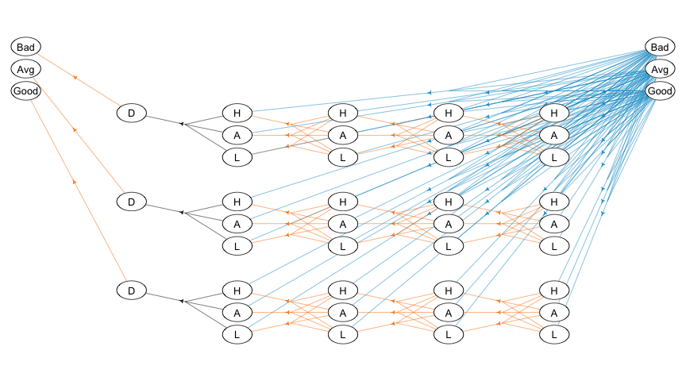

## References

Kristensen, A. R., and E. Jørgensen. 2000. “Multi-Level Hierarchic Markov Processes as a Framework for Herd Management Support.” *Annals of Operations Research* 94: 69–89. https://doi.org/10.1023/A:1018921201113.

Nielsen, L. R., and A. R. Kristensen. 2006. “Finding the $K$ Best Policies in a Finite-Horizon Markov Decision Process.” *European Journal of Operational Research* 175 (2): 1164–79. https://doi.org/10.1016/j.ejor.2005.06.011.

Tijms, Henk. C. 2003. *A First Course in Stochastic Models*. John Wiley & Sons Ltd.